# [R, Python 분석과 프로그래밍의 친구 (by R Friend)](https://rfriend.tistory.com/)

## [R Graphics 낮은 수준의 그래프 함수 (6) 범례 추가 : legend(x, y, legend, ...)](https://rfriend.tistory.com/158)

[R 분석과 프로그래밍/R 그래프_시각화](https://rfriend.tistory.com/category/R%20%EB%B6%84%EC%84%9D%EA%B3%BC%20%ED%94%84%EB%A1%9C%EA%B7%B8%EB%9E%98%EB%B0%8D/R%20%EA%B7%B8%EB%9E%98%ED%94%84_%EC%8B%9C%EA%B0%81%ED%99%94) 2016. 1. 10. 23:11

지난번 포스팅에서는 그래프에 추가적인 정보를 입력하는 낮은 수준의 그래프 함수(low level graphic functions) 중에서

(1) 제목, XY축 Label 추가하는 title()

(2) XY축의 형태를 변환하는 axis(side, ...)

(3) 직선 연결, 추가 : lines(x, y), abline(a, b), abline(h=y), abline(v=x)

(4) 점 추가 : points(x, y)

(5) 문자 추가 : text(x, y, labels, ...), mtext()

에 대해서 알아보았습니다.

**[ 낮은 수준의 그래프 함수 (Low level graphic function) ]**

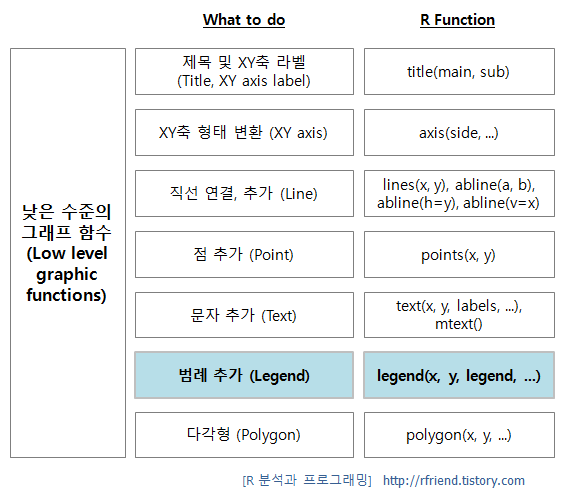

범례를 추가하는 legend()함수의 일반적인 사용법은 아래와 같습니다.

legend(x, y = NULL, legend, fill = NULL, col = par("col"),  
border = "black", lty, lwd, pch,  
angle = 45, density = NULL, bty = "o", bg = par("bg"),  
box.lwd = par("lwd"), box.lty = par("lty"), box.col = par("fg"),  
pt.bg = NA, cex = 1, pt.cex = cex, pt.lwd = lwd,  
xjust = 0, yjust = 1, x.intersp = 1, y.intersp = 1,  
adj = c(0, 0.5), text.width = NULL, text.col = par("col"),  
text.font = NULL, merge = do.lines && has.pch, trace = FALSE,  
plot = TRUE, ncol = 1, horiz = FALSE, title = NULL,  
inset = 0, xpd, title.col = text.col, title.adj = 0.5,  
seg.len = 2)

옵션이 굉장히 많지요? ^^; 그래프에 관한한 R 가지고 못하는게 거의 없다는게 바로 이런 겁니다. 그런데 이걸 다 설명하자니 시간이 너무 오래걸릴것 같기도 하고 대부분은 아마 거의 사용할 일이 없을 것 같기도 합니다. 그래서 많이 사용하는 옵션 위주로 몇 개만 선별해서 어려움없이 사용할 수 있는 정도로만 설명하겠습니다.

[output not shown]

MASS 패키지에 내장된 Cars93 데이터프레임의 차종(Type) 별로 차 무게(Weight)와 고속도로 연비 (MPG.highway) 변수를 사용해서 산포도를 그려보겠습니다. 그리고 차종(Type) 그룹에 대한 범례(legend)를 추가해보겠습니다.

**(1) x, y 좌표를 직접 입력하여 범례 위치 설정**

```
> # to use Cars93 dataframe
> library(MASS)
>
> # scatter plot
> attach(Cars93)
>
> # adding points with different characters by condition
> plot(Weight, MPG.highway, type = 'n') # blank plot
>
> # Type = Compact
> points(Weight[Type == "Compact"], MPG.highway[Type == "Compact"], pch = 0)
>
> # Type = Large
> points(Weight[Type == "Large"], MPG.highway[Type == "Large"], pch = 1)
>
> # Type = Midsize
> points(Weight[Type == "Midsize"], MPG.highway[Type == "Midsize"], pch = 17, col = "yellow")
>
> # Type = Small
> points(Weight[Type == "Small"], MPG.highway[Type == "Small"], pch = 3)
>
> # Type = Sporty
> points(Weight[Type == "Sporty"], MPG.highway[Type == "Sporty"], pch = 9)
>
> # Type = Van
> points(Weight[Type == "Van"], MPG.highway[Type == "Van"], pch = 15, col = "blue")
>
> title("adding legend to the plot")
>
>
> # adding legend to topright side
> legend(x = 3500, y = 50,
+        c("Compact", "Large", "Midsize", "Small", "Sporty", "Van"),
+        col = c("black", "black", "yellow", "black", "black", "blue"),
+        pch = c(0, 1, 17, 3, 9, 15)
+ )
>
```

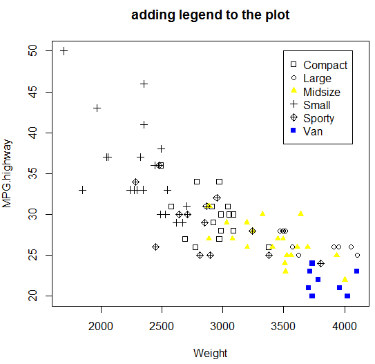

```
> detach(Cars93)
```

**(2) 위치를 나타내는 말을 직접 입력하여 범례 위치 설정**

```
> library(MASS)
> # scatter plot
> attach(Cars93)
> # adding points with different characters by condition
> plot(Weight, MPG.highway, type = 'n') # blank plot
> # Type = Compact
> points(Weight[Type == "Compact"], MPG.highway[Type == "Compact"], pch = 0)
>
> # Type = Large
> points(Weight[Type == "Large"], MPG.highway[Type == "Large"], pch = 1)
>
> # Type = Midsize
> points(Weight[Type == "Midsize"], MPG.highway[Type == "Midsize"], pch = 17, col = "yellow")
>
> # Type = Small
> points(Weight[Type == "Small"], MPG.highway[Type == "Small"], pch = 3)
>
> # Type = Sporty
> points(Weight[Type == "Sporty"], MPG.highway[Type == "Sporty"], pch = 9)
>
> # Type = Van
> points(Weight[Type == "Van"], MPG.highway[Type == "Van"], pch = 15, col = "blue")
>
> title("adding points with different characters by Car Types")
>
>
> # adding legend to topright side
> legend("topright",
+        c("Compact", "Large", "Midsize", "Small", "Sporty", "Van"),
+        col = c("black", "black", "yellow", "black", "black", "blue"),
+        pch = c(0, 1, 17, 3, 9, 15)
+        )
>
```

[figure not shown]

```
> detach(Cars93)
```

다음번 포스팅에서는 다각형(polygon)을 추가하는 방법에 대해서 소개하겠습니다.

많은 도움 되었기를 바랍니다.

이번 포스팅이 도움이 되었다면 아래의 '공감 ~♡' 단추를 꾸욱 눌러주세요.^^

[figure not shown]

[interactive chart not shown]

[저작자표시비영리변경금지](https://creativecommons.org/licenses/by-nc-nd/4.0/deed.ko)

[interactive chart not shown]

#### '[R 분석과 프로그래밍](https://rfriend.tistory.com/category/R%20%EB%B6%84%EC%84%9D%EA%B3%BC%20%ED%94%84%EB%A1%9C%EA%B7%B8%EB%9E%98%EB%B0%8D) > [R 그래프_시각화](https://rfriend.tistory.com/category/R%20%EB%B6%84%EC%84%9D%EA%B3%BC%20%ED%94%84%EB%A1%9C%EA%B7%B8%EB%9E%98%EB%B0%8D/R%20%EA%B7%B8%EB%9E%98%ED%94%84_%EC%8B%9C%EA%B0%81%ED%99%94)' 카테고리의 다른 글

[output not shown]

Posted by R Friend R_Friend

TAG [legend()](https://rfriend.tistory.com/tag/legend%28%29), [low level graphic function](https://rfriend.tistory.com/tag/low%20level%20graphic%20function), r, [R graphics](https://rfriend.tistory.com/tag/R%20graphics), [낮은 수준의 그래프 함수](https://rfriend.tistory.com/tag/%EB%82%AE%EC%9D%80%20%EC%88%98%EC%A4%80%EC%9D%98%20%EA%B7%B8%EB%9E%98%ED%94%84%20%ED%95%A8%EC%88%98), [범례 추가](https://rfriend.tistory.com/tag/%EB%B2%94%EB%A1%80%20%EC%B6%94%EA%B0%80)

트랙백 0개, 댓글 0개가 달렸습니다

### 댓글을 달아 주세요

비밀글

[interactive chart not shown]